# Homework 1

Michael Pearce

Due: October 10, 2022

## Explanatory Analyses

In this *swiss* dataset, we have 47 observations of 6 variables. The variable names are: Fertility, Agriculture, Examination, Education, Catholic, Infant.Mortality. In the interest of time, space, and mental exhaustion, let’s just pick one to explore!

Let’s see, maybe R can randomly pick something for us…

A random number generator gives us: 1. That corresponds to Fertility, cool! Now while it would be fun to do the rest of this assignment with a random variable, we can’t really make comments on plots and such without knowing it in advance. So it looks like we’re stuck with a regular ol’ summary table of all our variables here:

### Summary of *swiss* variables

| Fertility | Agriculture | Examination | Education | Catholic | Infant.Mortality |
| --- | --- | --- | --- | --- | --- |
| Min. :35.00 | Min. : 1.20 | Min. : 3.00 | Min. : 1.00 | Min. : 2.150 | Min. :10.80 |
| 1st Qu.:64.70 | 1st Qu.:35.90 | 1st Qu.:12.00 | 1st Qu.: 6.00 | 1st Qu.: 5.195 | 1st Qu.:18.15 |
| Median :70.40 | Median :54.10 | Median :16.00 | Median : 8.00 | Median : 15.140 | Median :20.00 |
| Mean :70.14 | Mean :50.66 | Mean :16.49 | Mean :10.98 | Mean : 41.144 | Mean :19.94 |
| 3rd Qu.:78.45 | 3rd Qu.:67.65 | 3rd Qu.:22.00 | 3rd Qu.:12.00 | 3rd Qu.: 93.125 | 3rd Qu.:21.70 |
| Max. :92.50 | Max. :89.70 | Max. :37.00 | Max. :53.00 | Max. :100.000 | Max. :26.60 |

Perhaps a closer look at Education would be interesting? Here’s a visual impression of its distribution:

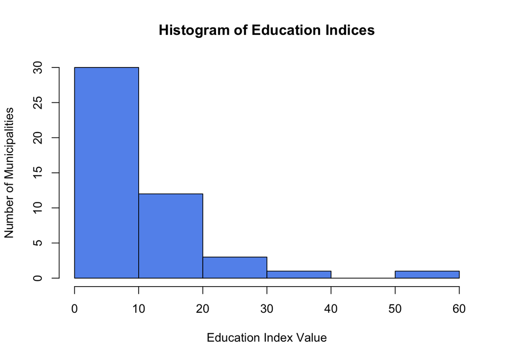

Hmm. A couple of those municipalities are way up there in this right-skewed distribution, specifically. As it stands currently, this variables has a mean of 10.98 and a standard deviation of 9.62. But since it’s so skewed, the median (8) is the better indicator of its center. It would be worth doing a log transformation to get a more normally distributed variable as we see below. We would definitely want to work with this transformed variable in any modeling.

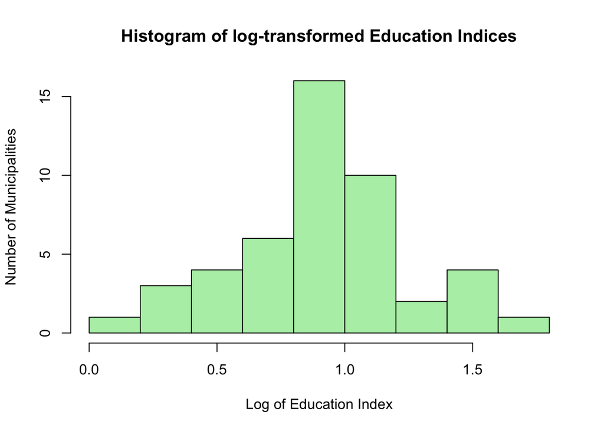

And finally, a pairwise scatterplot to give us an idea of correlative relationships to explore in the future. It’ll have to be tabled (heh) for now.

### Pairwise comparisons of *swiss* variables

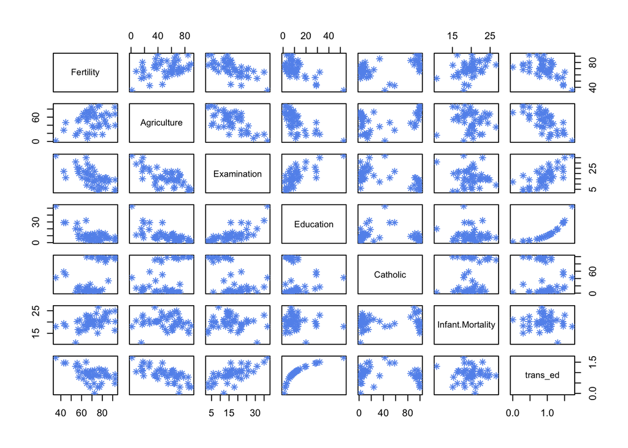